# Why countries trade (I)

Principles of Economics // Fall 2025

Prof. Santetti

marcio.santetti@emerson.edu

# Advantages

## Advantages

## Advantages

[Coffee consumption by country](https://worldpopulationreview.com/country-rankings/coffee-consumption-by-country)

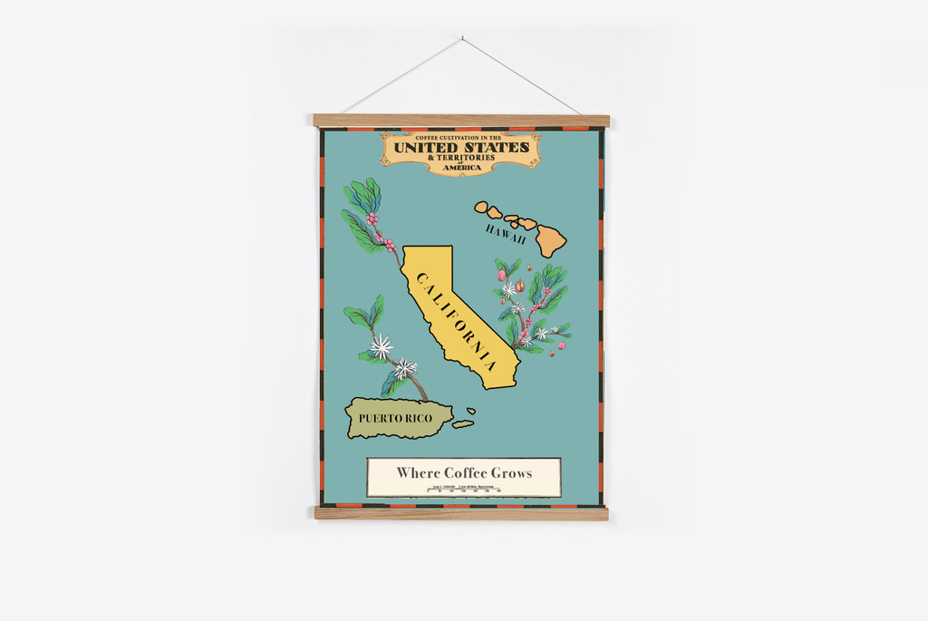

Source: [Sprudge](https://sprudge.com/coffee-basics-does-coffee-grow-in-the-united-states-179225.html)

## Advantages

A few cases:

- Oil
- Coffee
- Copper
- Corn
- iPhones
- Apparel

# The current context

## The current context

[Some data](https://wits.worldbank.org/trade/comtrade/en/country/USA/year/2023/tradeflow/Imports/partner/ALL/product/090500#:~:text=United%20States%20imports%20of%20Vanilla,3%2C064.58K%20%2C%2024%2C298%20Kg)

## The current context

An excerpt from this [Forbes piece](https://www.forbes.com/sites/hanktucker/2025/04/11/trumps-tariff-pause-gives-cinnamon-and-vanilla-lovers-relief-as-globalization-gets-a-reprieve/):

> *“Take vanilla: around 80% of America’s supply of it comes from Madagascar, one of the only places it can be produced thanks to about 100 inches of rainfall per year and humid temperatures between 68 and 86 degrees. President Trump’s widely discredited formula for calculating reciprocal tariff rates, which intended to eliminate trade deficits with around 90 countries, places Madagascar’s tariff at 47%, despite the fact that it would be impossible for the island nation of 31 million with a GDP per capita of $506 per year to import more than the $733 million it exports, mostly in vanilla, clothing, titanium, cobalt and nickel, to the United States.”*

## The current context

So…

By raising the cost of foreign-produced goods or services relative to locally produced ones, a tariff **redistributes** some of the benefits of trading from local consumers and foreign producers to local producers of import-competing goods.

# Barriers to trade

## Barriers to trade

- [Sugar quotas](https://www.sugarcane.org/sugarcane-products/sugar/sugar-trade/#usa-tariff-rate)
- [Commodities Subject to Import Quotas (U.S.)](https://www.cbp.gov/trade/quota/guide-import-goods/commodities)

## Barriers to trade

[U.S. Sanctions Programs and Country Information](https://ofac.treasury.gov/sanctions-programs-and-country-information)

# Tariffs (in general)

## Tariffs (in general)

WTO negotiations happen in “*rounds*,” where all countries negotiate one agreement to encourage trade, take a year or two off, and then start negotiating a new agreement.

[The WTO at 30: The return of higher tariffs (PIIE)](https://www.piie.com/commentary/speeches-papers/2025/wto-30-return-higher-tariffs)

[Why the US and the WTO should part ways (VoxEU)](https://cepr.org/voxeu/columns/why-us-and-wto-should-part-ways)

# Next time: Tariffs (the specifics)